# Tutorial: Bayesian models in R

Joshua Cook

10/24/2019

I stumbled across this tutorial on [*Bayesian modeling in R*](https://www.r-bloggers.com/bayesian-models-in-r-2/) and began reading through it. It was quite thorough on both theory and application, so I figured it would be a good one to follow more closely.

## Theory

### Maximum liklihood estimation

Say we are at a casino and playing roulette. We can bet on the color being either red ($r$) or black ($B$) with seemingly equal probability. The last 10 draws were 8 black and 2 reds:

$B, B, r, B, B, B, r, B, B, B$

Using the frequentist approach, we would assigned the probability of getting black as $f(B) = \frac{8}{10}$. This is the maiximum liklihood estimate, and would be a reasonable choice from a frequentist point-of-view. However, we can count the number of black and red squares and believe that the ball has a random chance of landing in any of them. Therefore, we believe that the probability of getting black should be $P(B) = 0.5$.

Alternatively, we can estimate the liklihood of getting the observed data (8 of 10 as black) over many different probabilities for getting black. In the plot below, the x-axis values are 100 different probabilities (between 0 and 1) of black ($P(B)$) and the y-axis is the liklihood of getting 8 blacks from 10 rounds (ie. 8 successes from 10 trials).

```r
# 100 values for P(B).
range_p <- seq(0, 1, length.out = 100)
# Liklihood of 8/10 given all trials probabilities.
densities <- dbinom(x = 8, prob = range_p, size = 10)
```

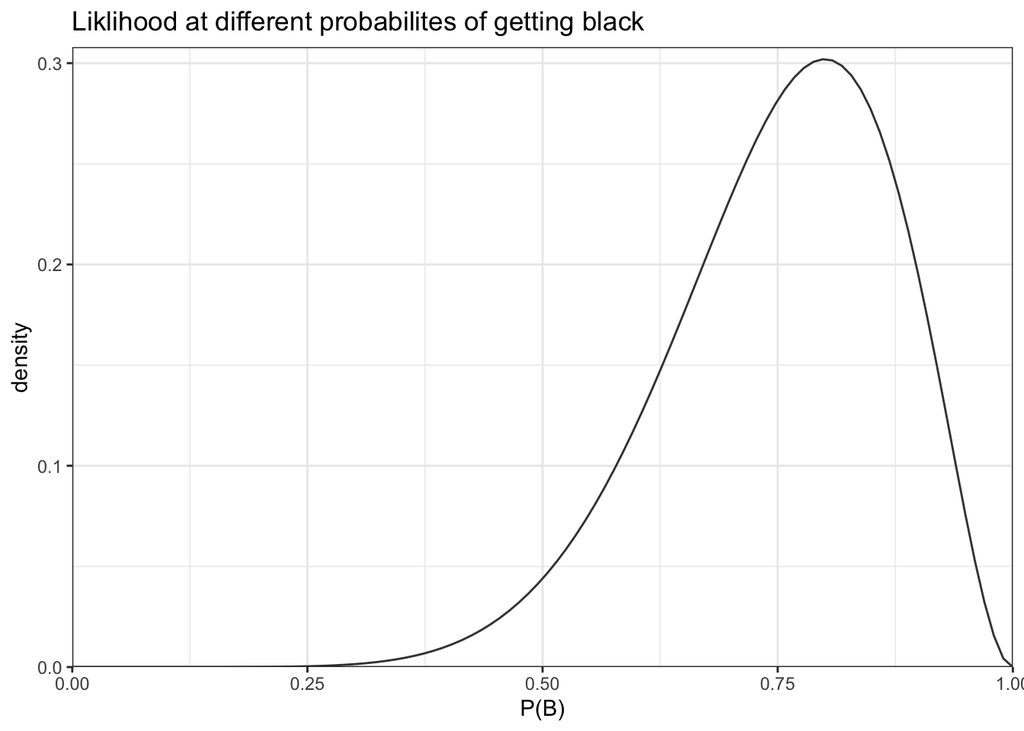

Our previous prediction for the probabiltiy of getting black was P(0.8) because it was the probability with the highest liklihood. This is why it was called the Maximum Liklihood Estimate (MLE).

### Update beliefs: the prior distribution

Though we observed 8 of 10 trials coming up black, we still have a feeling that the probability should be 0.5 because there are equal numbers of black and red slots where each one has equal probability of being selected. This is called the *prior* and it too has a distribution like that above (shown in red in the following plot). (For the plot, the values for the prior are scaled down for visualization purposes, though it does not effect the mathematics.)

```r
prior <- dnorm(x = range_p, mean = 0.5, sd = .1)
```

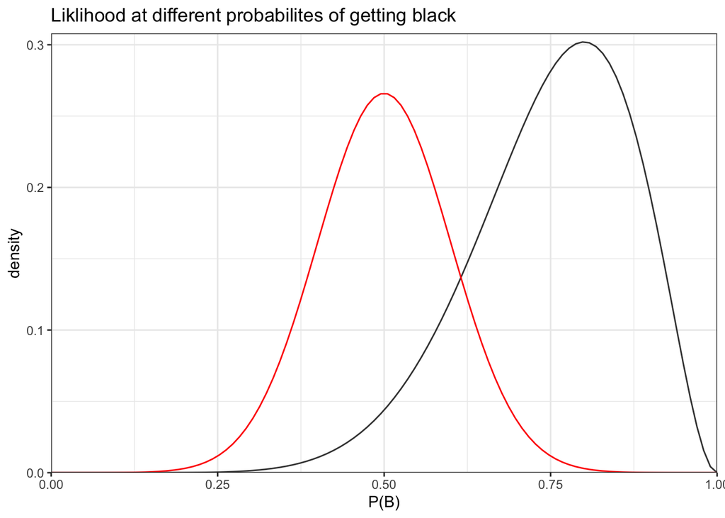

We can calculate the numerator for Bayes’ theorem by multiplying the liklihood of acheiving 8 of 10 black for each $P(B)$ by the prior distribution (shown in green below).

```r
lik <- dbinom(x = 8, prob = range_p, size = 10)
prior <- dnorm(x = range_p, mean = 0.5, sd = 0.1)
bt_numerator <- lik * prior
```

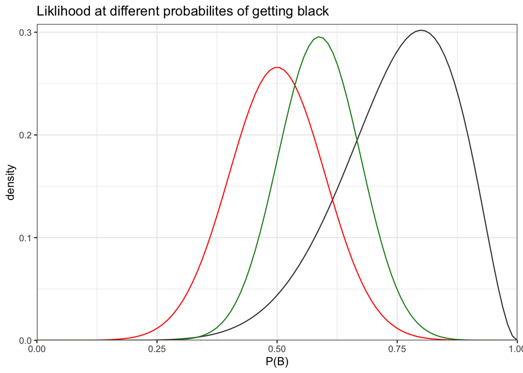

### Standardizing the posterior

The area under the curve of the probability mass function must sum to 1. In BT, this is solved by the denominator.

```r
bt_posterior <- bt_numerator / sum(bt_numerator)
```

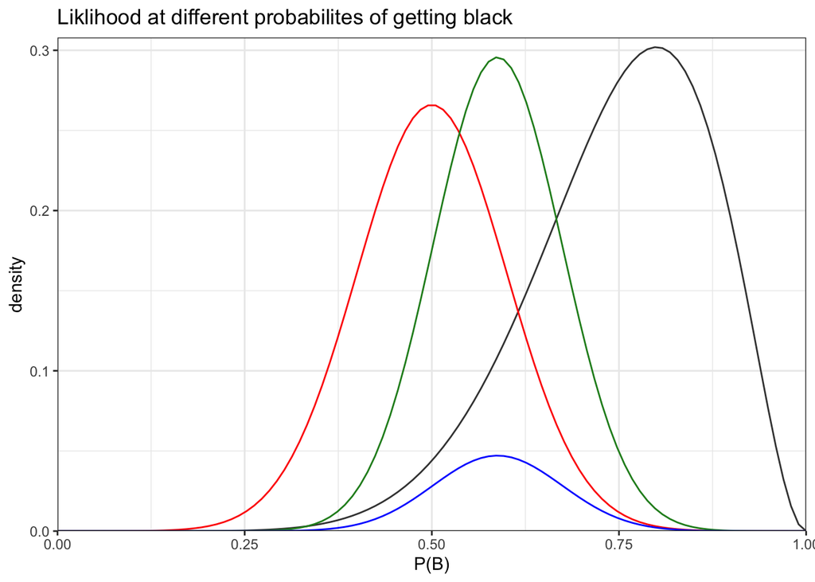

## Simulation

Here is another example, however this time, we will be estimating two paramters, $\mu$ and $\sigma$, from a normal distribution.

For the purpose of the simulation, we will set $\mu=5$ and $\sigma=2$, but the simulation will not know this. Here is the underlying model and our two priors.

$$\text{model:} \quad X \sim N(\mu, \sigma) \\
\text{priors:} \quad \mu \sim N(0,5) \quad \sigma \sim Exp(1)$$

Now we need the following components:

1. the grid of $\mu$ and $\sigma$ over which to search, we will use 200 values of each
2. compute the liklihood for each cell in the 200 x 200 grid
3. compute the product between the liklihoods and our priors
4. standardize the numerator

We begin by declaring the real, underlying values from which the data is sampled.

```r
# Declare the underlying values.
true_mu <- 5
true_sigma <- 2

# Sample from the distribution.
set.seed(0)
data_sample <- rnorm(100, true_mu, true_sigma)
```

The we create the grid for the search. We decided to try 200 values for each parameter, with various ranges that could be decided from the range of the sampled data.

```r
grid <- expand.grid(
    mu = seq(0, 10, length.out = 200),
    sigma = seq(1, 3, length.out = 200)
)
```

We now compute the liklihood for each cell, a value for $\mu$ and $\sigma$. Normaly, the liklihood of finding the data for a given $\mu$ and $\sigma$ would be found by taking the product of the probabilities: $Lik_i = \prod_{j=1}^{n} P(\mu_i, \sigma_i | X_j)$. However, a more computationally efficient mechanism is to take the sum in the log-scale: $Lik_i = \sum_{j=1}^{n} log(P(\mu_i, \sigma_i | X_j))$.

```r
# Calculate the liklihood of seeing `data` given a mean of `mu` and a
#   std. dev. of `sigma`.
calculate_liklihood <- function(data, mu, sigma) {
    sum(dnorm(x = data, mean = mu, sd = sigma, log = TRUE))
}

lik <- purrr::pmap_dbl(grid, calculate_liklihood, data = data_sample)
```

Then we can multiply the liklihoods with the priors. Since we are in log-scale, this means we add the priors.

```r
bt_numerator <- lik + dnorm(grid$mu, mean = 0, sd = 5, log = TRUE) + dexp(grid$sigma, 1, log = TRUE)
```

Finally, we need to standardize the numerator with the demonintator to bring the integral over the PMF to 1. We must do this in the exponent because we are in log-scale.

```r
bt_posterior <- exp(bt_numerator - max(bt_numerator))
```

Now we can plot the known and estimated values for $\mu$ and $\sigma$ on a sample taken from the posterior distribution.

```r
post_estimates <- grid[which.max(bt_posterior), ]
post_sample <- sample_n(grid, size = 1e3, weight = bt_posterior, replace = TRUE)
```

The posterior estimates are:

- $\mu$: 5.025
- $\sigma$: 1.744

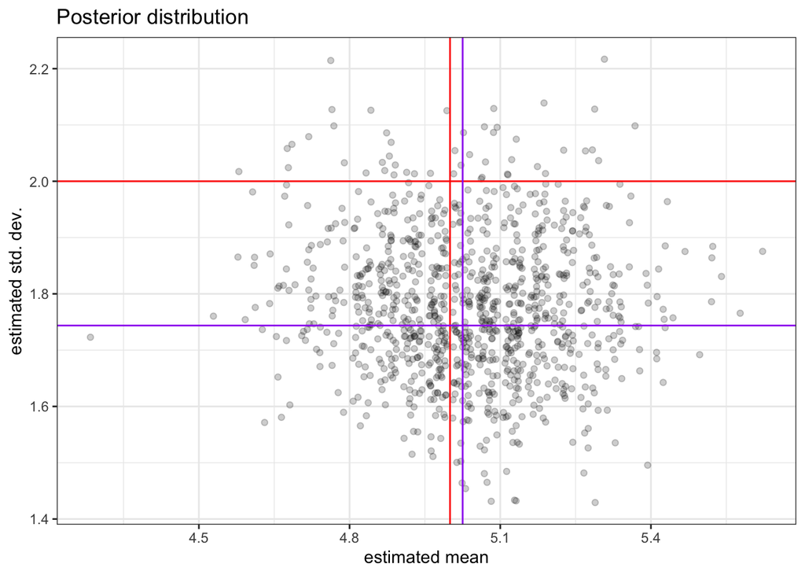

## Bayesian models and MCMC

The author recommends two packages for Bayesian modeling, [‘greta’](https://cran.r-project.org/web/packages/greta/index.html) and [‘rethinking’](https://github.com/rmcelreath/rethinking) (not on CRAN), and compares their features.

## Bayesian modeling in R

### Data

For this example, we used data collected for a study on the reproductive behaviour in *Crotophaga major*, a type of cuckoo. The females display both coopertative and parasitic nesting behaviour. There are three hypothesis we have for this study:

1. *super monther*: females have too many eggs for their own nests, therefore resort to parasitism
2. *specialized parasites*: some females engage in a life-long parasitic behaviour
3. *last resort*: parasitic behaviour is resorted to after a female loses her eggs or nest

### Analysis

To begin, we loaded the necessary libraries and read in the data. The data was downloaded from the [GitHub repository](https://github.com/monogenea/cuckooParasitism) accompanying the tutorial and was saved locally as “data/cuckoo_nesting_data.xlsx”.

```r
# The packages are actually loaded in the 'setup' chunk for the Rmd.
library(rethinking)
library(readxl)
library(tidyverse)
```

```r
data <- read_excel("data/cuckoo_nesting_data.xlsx") %>%
    as_tibble() %>%
    janitor::clean_names()
```

```
## # A tibble: 1,776 x 14
##     year group_id_code egg_number date_found          min_date_laid
##    <dbl> <chr>              <dbl> <dttm>              <dttm>
##  1  2007 NTE II                 4 2007-07-09 00:00:00 NA
##  2  2007 NTE II                 5 2007-07-11 00:00:00 2007-07-10 00:00:00
##  3  2007 NTE II                 6 2007-07-11 00:00:00 2007-07-10 00:00:00
##  4  2007 STH I                  1 2007-07-09 00:00:00 2007-07-07 00:00:00
##  5  2007 STH I                  2 2007-07-09 00:00:00 2007-07-07 00:00:00
##  6  2007 STH I                  3 2007-07-10 00:00:00 2007-07-09 00:00:00
##  7  2007 STH I                  4 2007-07-10 00:00:00 2007-07-09 00:00:00
##  8  2007 STH I                  5 2007-07-12 00:00:00 2007-07-11 00:00:00
##  9  2007 STH I                  6 2007-07-12 00:00:00 2007-07-11 00:00:00
## 10  2007 STH I                  7 2007-07-14 00:00:00 2007-07-13 00:00:00
## # … with 1,766 more rows, and 9 more variables: mass <chr>, length <chr>,
## #   width <chr>, fate <chr>, date_fate_recorded <chr>,
## #   female_genotype_coded <dbl>, parasitic <dbl>, dna_source <chr>,
## #   notes <chr>
```

```
## Skim summary statistics
##  n obs: 1776
##  n variables: 14
##
## ── Variable type:character ───────────────────────────────────────────────────────────────────────────────────────────────────────────
##            variable missing complete    n min max empty n_unique
##  date_fate_recorded     253     1523 1776   1   5     0      346
##          dna_source      57     1719 1776   1   7     0       13
##                fate       0     1776 1776   1   1     0       11
##       group_id_code       0     1776 1776   3   9     0      126
##              length     470     1306 1776   1  18     0      105
##                mass     468     1308 1776   1  18     0       89
##               notes    1356      420 1776   5 237     0      295
##               width     470     1306 1776   1  18     0       77
##
## ── Variable type:numeric ─────────────────────────────────────────────────────────────────────────────────────────────────────────────
##               variable missing complete    n       mean      sd    p0
##             egg_number       1     1775 1776    5.44    3.51        0
##  female_genotype_coded       7     1769 1776    4.3e+08 1.4e+08 3e+08
##              parasitic       0     1776 1776    0.037   0.19        0
##                   year       0     1776 1776 2012.18    3.72     2007
##    p25        p50        p75       p100     hist
##      3    5          7         20       ▆▇▅▅▁▁▁▁
##  3e+08    3.4e+08    5.6e+08    7.3e+08 ▇▁▁▁▃▂▁▁
##      0    0          0          1       ▇▁▁▁▁▁▁▁
##   2008 2013       2016       2017       ▇▂▁▃▂▃▂▇
##
## ── Variable type:POSIXct ─────────────────────────────────────────────────────────────────────────────────────────────────────────────
##       variable missing complete    n        min        max     median
##     date_found       4     1772 1776 2007-07-09 2017-09-02 2013-07-04
##  min_date_laid     519     1257 1776 2005-08-27 2017-09-01 2014-07-17
##  n_unique
##       414
##       406
```